# Laplace-EM in bigIRT: a step-by-step walkthrough

Mathematics, intuition, and comparison with JML and classical MML

## Purpose

This document explains the `marginalApprox = "laplace_em"` path in **bigIRT** in a way that complements the implementation-facing note `laplace-em-algorithm.md`. Here the focus is on *why* each step exists, how to picture it geometrically, and how the approach relates to **joint maximum likelihood (JML)** and **classical marginal maximum likelihood (MML)** for item response models with Gaussian ability priors.

Throughout, $\boldsymbol{\theta}_j \in \mathbb{R}^K$ denotes person $j$’s latent ability vector and $\boldsymbol{\xi}$ denotes item (and other structural) parameters.

## 1. What are we trying to maximize?

For binary responses, a common IRT setup (as used in bigIRT’s Laplace backend) writes a rowwise linear predictor
$$\eta_r = \mathbf{a}_r^\top \boldsymbol{\theta}_{j(r)} - b_r$$
and a four-parameter logistic probability
$$p_r = c_r + (d_r - c_r)\,\sigma(\eta_r), \qquad \sigma(x) =
\frac{1}{1+e^{-x}}.$$
Lower-dimensional PL models fix $c_r$ and/or $d_r$.

Assume responses are conditionally independent given $(\boldsymbol{\theta}, \boldsymbol{\xi})$ and that abilities are *a priori* Gaussian,
$$\boldsymbol{\theta}_j \sim \mathcal{N}(\boldsymbol{\mu}_j,
\mathbf{Q}_{0j}^{-1}),$$
with $\mathbf{Q}_{0j}$ a fixed precision matrix in the current Laplace loop (shared structure across persons except for fixed coordinates). The **marginal likelihood** for person $j$’s response vector $\mathbf{y}_j$ is
$$\mathcal{L}_j^{\mathrm{marg}}(\boldsymbol{\xi})
=
\int
\pi(\boldsymbol{\theta}_j \mid \boldsymbol{\mu}_j, \mathbf{Q}_{0j})\,
\prod_{r \in \mathcal{R}_j} p(y_r \mid \boldsymbol{\theta}_j,
\boldsymbol{\xi})\,
\mathrm{d}\boldsymbol{\theta}_j .$$
**Classical MML** estimation chooses $\boldsymbol{\xi}$ to maximize $\sum_j \log \mathcal{L}_j^{\mathrm{marg}}(\boldsymbol{\xi})$ (often plus priors on $\boldsymbol{\xi}$).

The integral is high-dimensional when $K>1$ and has no closed form for logistic IRT. Three broad strategies:

| Approach | Treats $\boldsymbol{\theta}$ as | Core optimization target |
| --- | --- | --- |
| **JML** | **Free parameters** (one vector per person) | Joint log-likelihood $\sum_{j,r} \log p(y_r \mid \boldsymbol{\theta}_j, \boldsymbol{\xi})$ (often with penalties/priors) |
| **MML (quadrature / numeric EM)** | **Integrated out** | $\sum_j \log \int (\cdots)\,\mathrm{d}\boldsymbol{\theta}_j$ via quadrature or Monte Carlo in the E-step |
| **Laplace MML (here: Laplace-EM)** | **Integrated out *approximately*** | Replace each $\int$ by a Gaussian integral around the **posterior mode** |

The bigIRT `laplace_em` path implements the third column: a **Laplace approximation** to each person’s marginal contribution, embedded in an **EM-style outer loop** over items and persons.

## 2. JML in one picture (and why MML exists)

### 2.1 Mathematical form

**JML** maximizes (schematically)
$$\ell_{\mathrm{JML}}(\boldsymbol{\theta}_{1:N}, \boldsymbol{\xi})
=
\sum_{j=1}^N \sum_{r \in \mathcal{R}_j} \log p(y_r \mid
\boldsymbol{\theta}_j, \boldsymbol{\xi})$$
possibly adding ability/item priors for numerical stability. The parameter count grows with sample size $N$ because each person carries a $\boldsymbol{\theta}_j$.

### 2.2 Intuition

Think of a **very high-dimensional surface**: you move *all* person ability vectors and *all* item parameters simultaneously to climb the joint likelihood. When $N$ is large, incidental person parameters create **Neyman–Scott**-style issues: item parameter estimates need not behave like well-behaved MLEs of a fixed-dimensional parameter; **JML item estimates are typically biased** (e.g., difficulty/extremity bias) unless the design or penalties correct it.

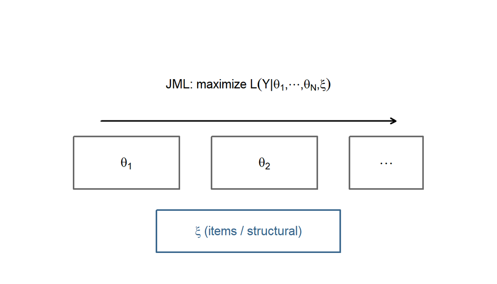

Schematic (not to scale): JML optimizes a joint objective over many person-specific coordinates plus item parameters. As N grows, the surface lives in a very high-dimensional space.

**Takeaway:** JML is conceptually simple and fast in some implementations, but it does **not** target the same inferential quantity as MML unless the prior/penalty approximates marginalization well.

## 3. Classical MML: the exact target

### 3.1 Log marginal likelihood

Up to an additive constant from the Gaussian prior density,
$$\log \mathcal{L}_j^{\mathrm{marg}}(\boldsymbol{\xi})
=
\log \int \exp\big\{ \log \pi(\boldsymbol{\theta}_j) + \sum_{r \in
\mathcal{R}_j} \log p(y_r \mid \boldsymbol{\theta}_j, \boldsymbol{\xi})
\big\}\,\mathrm{d}\boldsymbol{\theta}_j .$$
Define the **person-conditional log posterior** (for fixed $\boldsymbol{\xi}$)
$$\ell_j(\boldsymbol{\theta}_j)
=
-\tfrac{1}{2}(\boldsymbol{\theta}_j - \boldsymbol{\mu}_j)^\top
\mathbf{Q}_{0j}(\boldsymbol{\theta}_j - \boldsymbol{\mu}_j)
+
\sum_{r \in \mathcal{R}_j} \log p(y_r \mid \boldsymbol{\theta}_j,
\boldsymbol{\xi})$$
(ignoring constants). Then the marginal log-density is a **log-integral of an exponential**—a **log-sum-exp** over the whole space—exactly the object EM and quadrature methods approximate.

### 3.2 Classical EM / quadrature picture

**Unidimensional** models ($K=1$): Bock–Lieberman-style **Gauss–Hermite quadrature** replaces the integral by a weighted sum on a grid. **EM** alternates:

- **E-step:** compute posterior expectations of complete-data sufficient statistics (or use quadrature expectations).
- **M-step:** update $\boldsymbol{\xi}$ to increase the **Q-function** built from those expectations.

**Multidimensional** $K>1$: grids explode (curse of dimensionality). Practitioners use **adaptive quadrature**, **MHRM / Metropolis**, **variational** methods, or **Laplace** approximations.

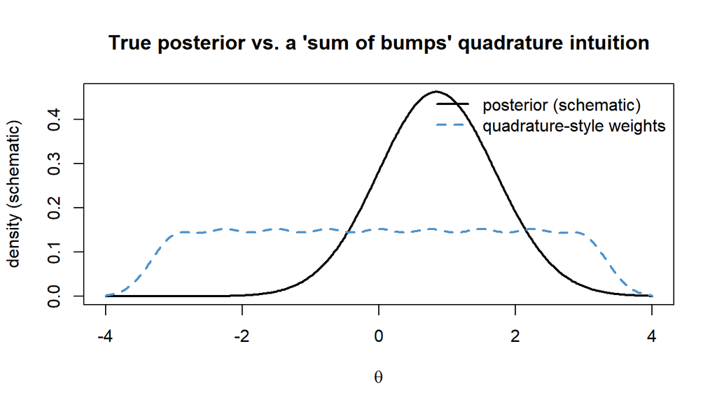

1D intuition only: classical MML can approximate the marginal likelihood integral by weighted mass on ability nodes (quadrature). In higher dimensions, grids are replaced by smarter integration or local approximations.

**Takeaway:** classical MML is **statistically principled** for item calibration when the ability prior reflects the target population, but **computation** is the hard part in MIRT.

## 4. Laplace approximation: replace a peak by a Gaussian

### 4.1 Taylor expansion at the posterior mode

Let $\hat{\boldsymbol{\theta}}_j = \arg\max_{\boldsymbol{\theta}} \ell_j(\boldsymbol{\theta})$ be the **posterior mode** given current $\boldsymbol{\xi}$. Expand $\ell_j$ to second order:
$$\ell_j(\boldsymbol{\theta}) \approx \ell_j(\hat{\boldsymbol{\theta}}_j)
-
\tfrac{1}{2}(\boldsymbol{\theta} - \hat{\boldsymbol{\theta}}_j)^\top
\mathbf{H}_j (\boldsymbol{\theta} - \hat{\boldsymbol{\theta}}_j),$$
where $\mathbf{H}_j$ is a positive-definite **precision** matrix approximating $-\nabla^2 \ell_j(\hat{\boldsymbol{\theta}}_j)$.

Then, by the multivariate Gaussian integral formula,
$$\int \exp\{\ell_j(\boldsymbol{\theta})\}\,\mathrm{d}\boldsymbol{\theta}
\approx
\exp\{\ell_j(\hat{\boldsymbol{\theta}}_j)\}\,
(2\pi)^{K/2}\, |\mathbf{H}_j|^{-1/2}.$$
So (again up to additive constants independent of $\boldsymbol{\xi}$ in standard treatments),
$$\log \mathcal{L}_j^{\mathrm{marg}}(\boldsymbol{\xi})
\approx
\underbrace{\sum_{r \in \mathcal{R}_j} \log p(y_r \mid
\hat{\boldsymbol{\theta}}_j, \boldsymbol{\xi})}_{\text{plug-in
log-likelihood}}
+
\underbrace{\tfrac{K}{2}\log(2\pi) - \tfrac{1}{2}\log
|\mathbf{H}_j|}_{\text{Laplace / Occam correction}} .$$

### 4.2 Visual intuition (univariate)

[figure not shown]

```r
theta <- seq(-4, 4, length.out = 501)
log_post <- -(theta - 0.35)^2 / (2 * 0.85^2) + 1.2 * plogis(1.1 * (theta - 0.2), log.p = TRUE)
log_post <- log_post - max(log_post)
post <- exp(log_post)
post <- post / sum(post) / diff(theta)[1]

i_max <- which.max(post)
th_hat <- theta[i_max]
h <- 1e-3
d2 <- (log_post[which.min(abs(theta - (th_hat + h)))] - 2 * log_post[i_max] +
       log_post[which.min(abs(theta - (th_hat - h)))]) / h^2
prec <- -d2
sd_lap <- 1 / sqrt(prec)
lap <- dnorm(theta, mean = th_hat, sd = sd_lap)

plot(theta, post, type = "l", lwd = 2, xlab = expression(theta), ylab = "density (unnormalized scale)",
     main = "Posterior-like curve vs. Laplace Gaussian at the mode")
lines(theta, lap * max(post) / max(lap), lwd = 2, col = "steelblue3", lty = 2)
legend("topleft", legend = c("target shape", "Laplace quadratic / Gaussian"), col = c("black", "steelblue3"), lty = c(1, 2), lwd = 2, bty = "n")
```

**Takeaway:** Laplace MML keeps the **MML spirit** (integrate out $\boldsymbol{\theta}$) but **localizes** integration to a neighborhood of $\hat{\boldsymbol{\theta}}_j$, trading bias for speed—especially attractive in **moderate $K$** MIRT.

## 5. bigIRT’s person step: find the mode and curvature

This section matches `laplace-em-algorithm.md` and the C++ person update.

### 5.1 Person objective

For fixed $\boldsymbol{\xi}$, bigIRT maximizes
$$\ell_j(\boldsymbol{\theta}_j)
=
-\tfrac{1}{2}(\boldsymbol{\theta}_j - \boldsymbol{\mu}_j)^\top
\mathbf{Q}_{0j}(\boldsymbol{\theta}_j - \boldsymbol{\mu}_j)
+
\sum_{r \in \mathcal{R}_j} \log p(y_r \mid \boldsymbol{\theta}_j).$$

### 5.2 Gradient

With the rowwise chain rule through $\eta_r$, the implementation forms a scalar score $g_{\eta,r}$ for each row and accumulates
$$\nabla_{\boldsymbol{\theta}_j} \ell_j
=
-\mathbf{Q}_{0j}(\boldsymbol{\theta}_j - \boldsymbol{\mu}_j)
+
\sum_{r \in \mathcal{R}_j} g_{\eta,r}\, \mathbf{a}_r .$$

### 5.3 Precision matrix used in code

Rather than the full observed Hessian, the implementation uses an **expected-information style** rank-one sum
$$\mathbf{H}_j
=
\mathbf{Q}_{0j} + \sum_{r \in \mathcal{R}_j} w_r\, \mathbf{a}_r
\mathbf{a}_r^\top,
\qquad
w_r = \frac{s_r^2}{p_r(1-p_r)},$$
with $s_r$ the derivative of $p_r$ with respect to $\eta_r$, then adds small **jitter** for Cholesky stability. This $\mathbf{H}_j$ plays the role of the Laplace precision.

### 5.4 Numerical mode finding

The routine applies **damped Newton** steps
$$\boldsymbol{\theta}_j^{\mathrm{new}}
=
\boldsymbol{\theta}_j + \lambda\, \mathbf{H}_j^{-1}
\nabla_{\boldsymbol{\theta}_j} \ell_j$$
with backtracking on $\lambda$ until $\ell_j$ increases.

**Intuition:** you are solving a **MAP ability estimate** problem per person, but the curvature $\mathbf{H}_j$ is simultaneously the object that will enter the **$\log |\mathbf{H}_j|$** correction when updating items.

## 6. bigIRT’s item step: a Laplace-based surrogate (generalized EM)

Exact Laplace MML would differentiate **through** the implicit map $\hat{\boldsymbol{\theta}}_j(\boldsymbol{\xi})$ when updating $\boldsymbol{\xi}$. The current `laplace_em` implementation uses a **frozen-mode surrogate** at the person modes from the latest person pass:

$$\tilde{L}(\boldsymbol{\xi})
=
\sum_{j=1}^N
\left[
\sum_{r \in \mathcal{R}_j} \log p(y_r \mid \hat{\boldsymbol{\theta}}_j,
\boldsymbol{\xi})
+
\tfrac{K}{2}\log(2\pi)
-
\tfrac{1}{2}\log |\mathbf{H}_j(\boldsymbol{\xi} \mid
\hat{\boldsymbol{\theta}}_j)|
\right]
+
\log \pi(\boldsymbol{\xi}).$$

Important details (see the implementation note):

- $\hat{\boldsymbol{\theta}}_j$ is **held fixed** during the item optimization pass.
- $\mathbf{H}_j$ is **recomputed** from the *current* $\boldsymbol{\xi}$ and those fixed modes, and the **gradient includes derivatives** of $-\tfrac{1}{2}\log|\mathbf{H}_j|$.

So this is best read as a **generalized EM**-style construction: it is **not** yet full “exact Laplace marginal likelihood” with complete sensitivity of $\hat{\boldsymbol{\theta}}_j$ to $\boldsymbol{\xi}$ inside the item step.

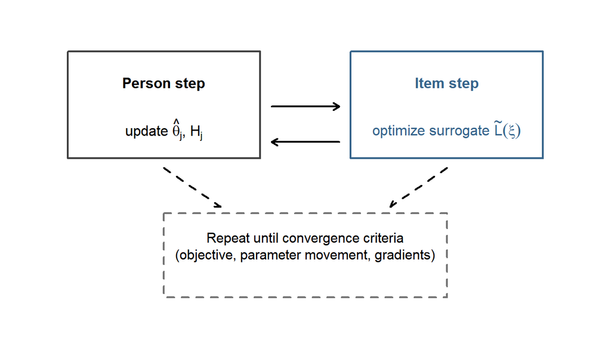

Outer structure: alternate ‘person / latent state’ improvements with ‘item parameter’ improvements under a Laplace-flavored surrogate.

## 7. Side-by-side comparison: JML vs classical MML vs Laplace-EM (bigIRT)

| Aspect | **JML** | **Classical MML** | **Laplace-EM (`laplace_em`)** |
| --- | --- | --- | --- |
| **Primary goal** | Fit data with explicit $\boldsymbol{\theta}_j$ | Calibrate items under population ability prior | Same *intent* as MML, with a local Gaussian integral |
| **Person side** | Parameters to optimize | Latent variables integrated (expectations / sums) | Find posterior **mode** + **precision** |
| **Item side** | Joint update with all $\boldsymbol{\theta}_j$ | M-step from E-step expectations | Optimize surrogate with $\log\|\mathbf{H}_j\|$ term |
| **Typical bias** | Item estimates often biased (incidental parameters) | Less incidental-parameter bias (with sensible prior) | Approximation error + frozen-mode surrogate gap vs exact MML |
| **Computation** | Can be fast; dimension huge | Quadrature costly in $K$; MCMC slower | Often practical for moderate $K$ MIRT |

**Conceptual slogan:**

- **JML:** “Make every person’s $\boldsymbol{\theta}_j$ explain their items *exactly as parameters*.”
- **Classical MML:** “Average over plausible $\boldsymbol{\theta}_j$ under the prior.”
- **Laplace-EM (bigIRT):** “Believe the posterior is sharply peaked; keep the peak and curvature, and let $\log|\mathbf{H}|$ remember that volume matters.”

## 8. How this fits the rest of bigIRT

- **Initialization:** the active `laplace_em` path uses a **prior-anchored** start (not a JML pre-fit); see `laplace-em-algorithm.md` for details.
- **Priors on items:** Gaussian priors on transformed item parameters are added in the R layer and enter the item objective and gradient.
- **Stopping rules:** the outer loop can terminate under **strict** tolerance (including item-gradient checks) or a **stability** path with patience when gradients remain noisy.

For symbol-level correspondence to code, see the “Mapping to code” section of `laplace-em-algorithm.md` (`R/laplaceBackend.R`, `src/laplace_backend.cpp`, `R/fitIRT.R`).

## 9. Outer loop implementation snapshot

This mirrors the `laplace_em` block in `fitIRT()` and the detailed list in `laplace-em-algorithm.md`.

1. **Initialization.** Person coordinates start at the prior mean (for free abilities); item parameters use simple heuristics (e.g., difficulty from marginal easiness at $\boldsymbol{\theta} = \boldsymbol{\mu}$). The path does **not** require a JML pre-fit.
2. **Fixed prior precision.** During the Laplace iterations, $\mathbf{Q}_{0j} = \boldsymbol{\Sigma}_0^{-1}$ is held fixed from user settings (`AbilitySD`, `AbilityCorr`).
3. **Each outer iteration $t$.**
   - **Person step:** update modes $\hat{\boldsymbol{\theta}}_j^{(t)}$ and precisions $\mathbf{H}_j^{(t)}$.
   - **Item step:** optimize the frozen-mode surrogate $\tilde{L}(\boldsymbol{\xi})$ while recomputing $\mathbf{H}_j(\boldsymbol{\xi} \mid \hat{\boldsymbol{\theta}}_j^{(t)})$.
   - **Person refresh:** recompute $\hat{\boldsymbol{\theta}}_j$ and $\mathbf{H}_j$ under the new $\boldsymbol{\xi}$.
   - **Monitor** surrogate value and parameter movement.
4. **Stopping.** Either **strict** convergence (tight objective, small RMS moves, small person updates, small item-step gradient norm for two consecutive passes) or **stability** patience when improvement is small but item gradients remain somewhat large; otherwise stop at `laplaceOuterIter`.

**Flow (same loop as the EM-style schematic figure above):** initialize → person step → item step → refresh persons → check convergence → repeat.

## 10. Further reading (standard references)

- Bock & Lieberman (1970) and Bock & Aitkin (1981): EM + quadrature foundations for MML in IRT.
- Tierney & Kadane (1986): Laplace’s method for integrals in Bayesian inference (general methodology).
- Baker & Kim (2004): textbook treatment of JML vs MML perspectives.

These citations are **expository**; for **bigIRT’s exact objective and gradients**, treat `laplace-em-algorithm.md` as authoritative.